# Motor Trend: Automatic vs Manual for Gas Mileage

### Multivariable Regression

Before adding variables to the regression model, we must determine what other data strongly correlates with mpg.

```r
data(mtcars)    # resets all data to numerical to work with cor() function
cor(mtcars)[1,]
```

```
##        mpg        cyl       disp         hp       drat         wt
##  1.0000000 -0.8521620 -0.8475514 -0.7761684  0.6811719 -0.8676594
##       qsec         vs         am       gear       carb
##  0.4186840  0.6640389  0.5998324  0.4802848 -0.5509251
```

As we can see, the variables that strongly correlate with mpg are number of cylinders (*cyl*), displacement (*disp*), gross horsepower (*hp*), and 1000 lbs of weight (*wt*). *Figure 2, Appendix A* gives a visualization of these correlations. Now that we found the other variables strongly affecting the *mpg*, we can create a new linear model

```r
for(i in c(2,8:11)){    # Changes the class of all the categorical variables back to factors
  mtcars[,i] <- as.factor(mtcars[,i])
}
mtcars$am <- factor(mtcars$am,levels=c(0,1),labels=c("Automatic", "Manual"))

multivar <- lm(mpg ~ am + wt + cyl + disp + hp, data = mtcars)
multivar_lm <- summary(multivar)
multivar_lm
```

```
##
## Call:
## lm(formula = mpg ~ am + wt + cyl + disp + hp, data = mtcars)
##
## Residuals:
##     Min      1Q  Median      3Q     Max
## -3.9374 -1.3347 -0.3903  1.1910  5.0757
##
## Coefficients:
##              Estimate Std. Error t value Pr(>|t|)
## (Intercept) 33.864276   2.695416  12.564 2.67e-12 ***
## amManual     1.806099   1.421079   1.271   0.2155
## wt          -2.738695   1.175978  -2.329   0.0282 *
## cyl6        -3.136067   1.469090  -2.135   0.0428 *
## cyl8        -2.717781   2.898149  -0.938   0.3573
## disp         0.004088   0.012767   0.320   0.7515
## hp          -0.032480   0.013983  -2.323   0.0286 *
## ---
## Signif. codes:  0 '***' 0.001 '**' 0.01 '*' 0.05 '.' 0.1 ' ' 1
##
## Residual standard error: 2.453 on 25 degrees of freedom
## Multiple R-squared:  0.8664, Adjusted R-squared:  0.8344
## F-statistic: 27.03 on 6 and 25 DF,  p-value: 8.861e-10
```

# Appendix A

### *Figure 1*: MPG by Transmission Type

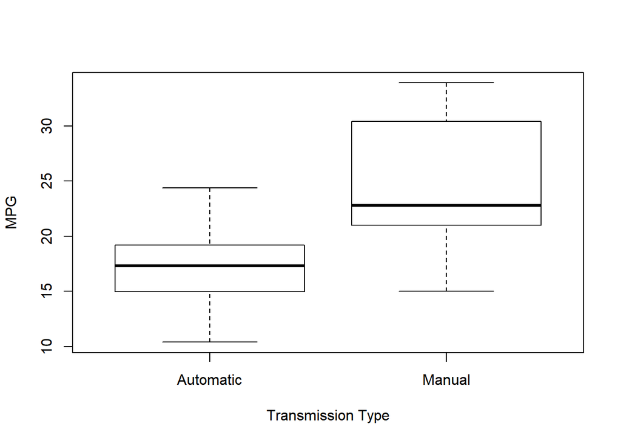

```r
boxplot(
  mpg ~ am, data = mtcars,
  xlab = "Transmission Type", ylab = "MPG"
)
```

### *Figure 2*: Correlation Between All Variables

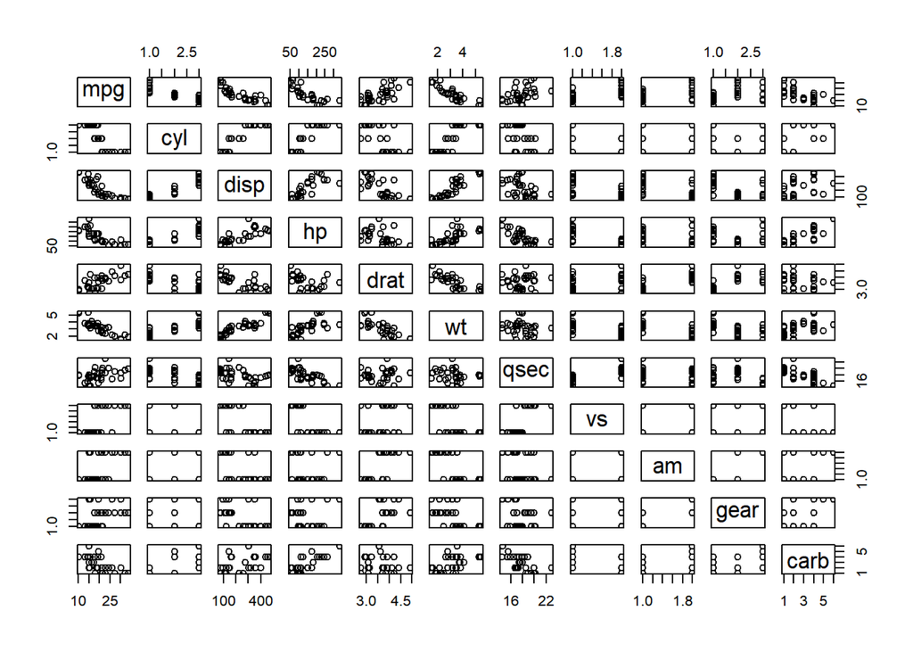

```r
pairs(mpg ~ ., data = mtcars)
```

### *Figure 3*: Residual Values

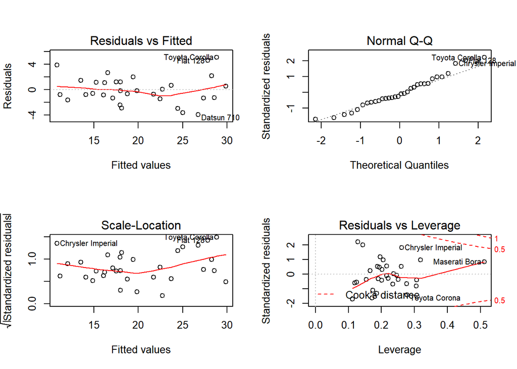

```r
par(mfrow=c(2,2))
plot(multivar)
```